# 11 Tutorial

# Preamble

## Load Packages

```r
load.pac <- function() {

  if(require("pacman")){
    library(pacman)
  }else{
    install.packages("pacman")
    library(pacman)
  }

  pacman::p_load(xts, sp, gstat, ggplot2, rmarkdown, reshape2, ggmap, wesanderson,
                 parallel, dplyr, plotly, tidyverse, reticulate, UsingR, Rmpfr, latex2exp,
                 mise, GGally, usmap, gridExtra)

#  devtools::install_github("tidyverse/tidyverse")
}

load.pac()
mise()
```

## Load Data I couldn’t get `read_xls` to work so I just used *Libre Office* to export them.

```r
(orders  <- read.csv(file = "./11_Data_Orders.csv"))  %>% head()
```

|  | Row.ID | Order.ID | Order.Date | Ship.Date | Ship.Mode | Customer.ID | Customer.Name | Segment | Country | City | State | Postal.Code | Region | Product.ID | Category | Sub.Category | Product.Name | Sales | Quantity | Discount | Profit |
| --- | --- | --- | --- | --- | --- | --- | --- | --- | --- | --- | --- | --- | --- | --- | --- | --- | --- | --- | --- | --- | --- |
| 1 | 1 | CA-2013-152156 | 9/11/2013 | 12/11/2013 | Second Class | CG-12520 | Claire Gute | Consumer | United States | Henderson | Kentucky | 42420 | South | FUR-BO-10001798 | Furniture | Bookcases | Bush Somerset Collection Bookcase | 261.9600 | 2 | 0.00 | 41.9136 |
| 2 | 2 | CA-2013-152156 | 9/11/2013 | 12/11/2013 | Second Class | CG-12520 | Claire Gute | Consumer | United States | Henderson | Kentucky | 42420 | South | FUR-CH-10000454 | Furniture | Chairs | Hon Deluxe Fabric Upholstered Stacking Chairs, Rounded Back | 731.9400 | 3 | 0.00 | 219.5820 |
| 3 | 3 | CA-2013-138688 | 13/06/2013 | 17/06/2013 | Second Class | DV-13045 | Darrin Van Huff | Corporate | United States | Los Angeles | California | 90036 | West | OFF-LA-10000240 | Office Supplies | Labels | Self-Adhesive Address Labels for Typewriters by Universal | 14.6200 | 2 | 0.00 | 6.8714 |
| 4 | 4 | US-2012-108966 | 11/10/2012 | 18/10/2012 | Standard Class | SO-20335 | Sean O'Donnell | Consumer | United States | Fort Lauderdale | Florida | 33311 | South | FUR-TA-10000577 | Furniture | Tables | Bretford CR4500 Series Slim Rectangular Table | 957.5775 | 5 | 0.45 | -383.0310 |
| 5 | 5 | US-2012-108966 | 11/10/2012 | 18/10/2012 | Standard Class | SO-20335 | Sean O'Donnell | Consumer | United States | Fort Lauderdale | Florida | 33311 | South | OFF-ST-10000760 | Office Supplies | Storage | Eldon Fold 'N Roll Cart System | 22.3680 | 2 | 0.20 | 2.5164 |
| 6 | 6 | CA-2011-115812 | 9/06/2011 | 14/06/2011 | Standard Class | BH-11710 | Brosina Hoffman | Consumer | United States | Los Angeles | California | 90032 | West | FUR-FU-10001487 | Furniture | Furnishings | Eldon Expressions Wood and Plastic Desk Accessories, Cherry Wood | 48.8600 | 7 | 0.00 | 14.1694 |

```r
(returns <- read.csv(file = "./11_Data_Returns.csv")) %>% head()
```

|  | Returned | Order.ID |
| --- | --- | --- |
| 1 | Yes | CA-2014-153822 |
| 2 | Yes | CA-2014-129707 |
| 3 | Yes | CA-2011-152345 |
| 4 | Yes | CA-2012-156440 |
| 5 | Yes | US-2014-155999 |
| 6 | Yes | CA-2011-157924 |

```r
(peopl   <- read.csv(file = "./11_Data_People.csv"))  %>% head()
```

|  | Person | Region |
| --- | --- | --- |
| 1 | Anna Andreadi | West |
| 2 | Chuck Magee | East |
| 3 | Kelly Williams | Central |
| 4 | Cassandra Brandow | South |

# Question 1

> Visualise the Data

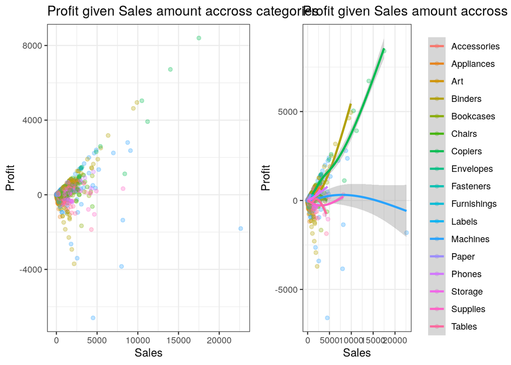

```r
orders$Ship.Date <- as.Date(orders$Ship.Date, format = "%d/%m/%Y")
orders$Order.Date <- as.Date(orders$Order.Date, format = "%d/%m/%Y")
## ggplot(orders, aes(x = Order.Date, y = Sales, col = Sub.Category)) +
##   geom_col()


ppt <- ggplot(orders, aes(x = Sales, y = Profit, col = Sub.Category)) +
  geom_point(alpha = 0.3) +
  theme_bw() +
  geom_smooth() +
  guides(col = guide_legend("")) +
  labs(title = "Profit given Sales amount accross categories")

ppl <- ggplot(orders, aes(x = Sales, y = Profit, col = Sub.Category)) +
  geom_point(alpha = 0.3) +
  theme_bw() +
  guides(col = FALSE) +
  labs(title = "Profit given Sales amount accross categories")


grid.arrange(grobs = list(ppt, ppl), layout_matrix = matrix(2:1, nrow = 1))
```

## (a) Change the Mark Size

The size of the points can be increased by specifying the `size` parameter in the `geom_point` layer:

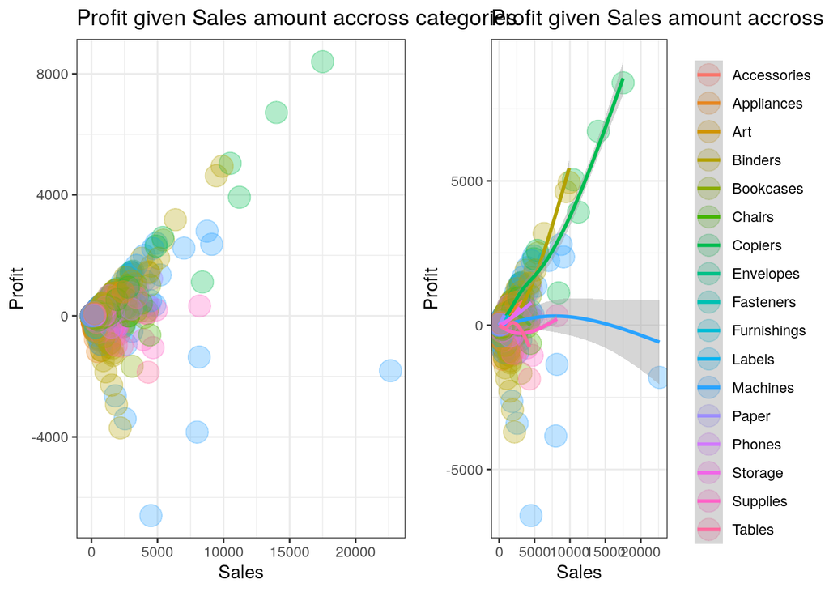

```r
ppt <- ggplot(orders, aes(x = Sales, y = Profit, col = Sub.Category)) +
  geom_point(alpha = 0.3, size = 6) +
  theme_bw() +
  geom_smooth() +
  guides(col = guide_legend("")) +
  labs(title = "Profit given Sales amount accross categories")

ppl <- ggplot(orders, aes(x = Sales, y = Profit, col = Sub.Category)) +
  geom_point(alpha = 0.3, size = 6) +
  theme_bw() +
  guides(col = FALSE) +
  labs(title = "Profit given Sales amount accross categories")


grid.arrange(grobs = list(ppt, ppl), layout_matrix = matrix(2:1, nrow = 1))
```

The size could even be mapped to another variable, say for example the Discount

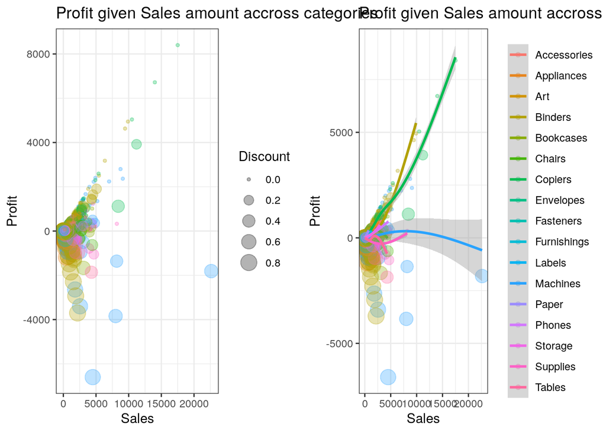

```r
ppt <- ggplot(orders, aes(x = Sales, y = Profit, col = Sub.Category)) +
  geom_point(alpha = 0.3, aes(size = Discount)) +
  theme_bw() +
  geom_smooth() +
  guides(col = guide_legend(""), size = FALSE) +
  labs(title = "Profit given Sales amount accross categories")

ppl <- ggplot(orders, aes(x = Sales, y = Profit, col = Sub.Category)) +
  geom_point(alpha = 0.3, aes(size = Discount)) +
  theme_bw() +
  guides(col = FALSE) +
  labs(title = "Profit given Sales amount accross categories")


grid.arrange(grobs = list(ppt, ppl), layout_matrix = matrix(2:1, nrow = 1))
```

This indicates that discounts hurt profits.

## (b) Customise the Shapes

The shapes could be mapped to anything, even to say unicode:

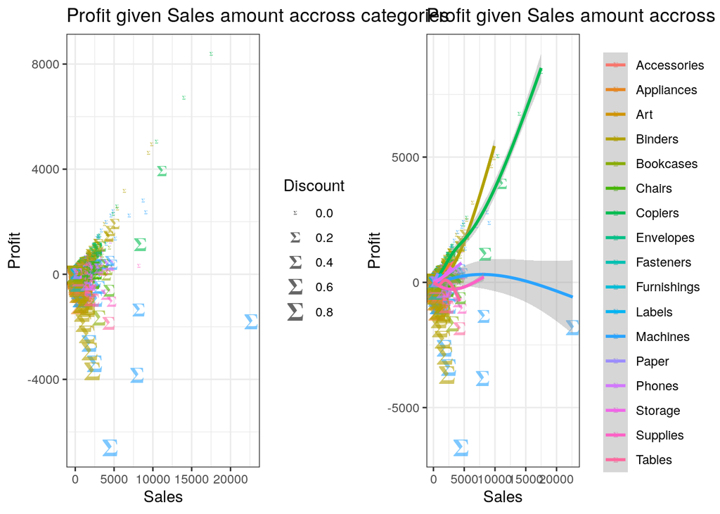

```r
ppt <- ggplot(orders, aes(x = Sales, y = Profit, col = Sub.Category)) +
  geom_point(alpha = 0.6, aes(size = Discount), shape = "𝚺") +
  theme_bw() +
  geom_smooth() +
  guides(col = guide_legend(""), size = FALSE) +
  labs(title = "Profit given Sales amount accross categories")

ppl <- ggplot(orders, aes(x = Sales, y = Profit, col = Sub.Category)) +
  geom_point(alpha = 0.6, aes(size = Discount), shape = "𝚺") +
  theme_bw() +
  guides(col = FALSE) +
  labs(title = "Profit given Sales amount accross categories")


grid.arrange(grobs = list(ppt, ppl), layout_matrix = matrix(2:1, nrow = 1))
```

It would be preferable however to map shape to some variable, say for example above/below average quantity:

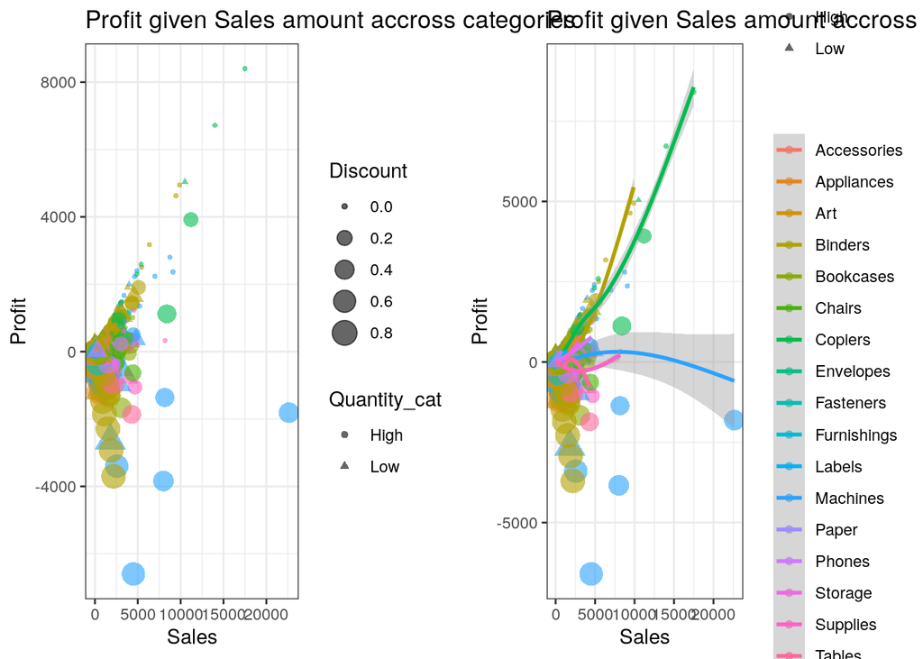

```r
orders$Quantity_cat <- factor(ifelse(orders$Quantity > mean(orders$Quantity), "High", "Low"), levels = c("High", "Low"), ordered = FALSE)

ppt <- ggplot(orders, aes(x = Sales, y = Profit, col = Sub.Category)) +
  geom_point(alpha = 0.6, aes(size = Discount, shape = Quantity_cat)) +
  theme_bw() +
  geom_smooth() +
  guides(col = guide_legend(""), size = FALSE) +
  labs(title = "Profit given Sales amount accross categories")

ppl <- ggplot(orders, aes(x = Sales, y = Profit, col = Sub.Category)) +
  geom_point(alpha = 0.6, aes(size = Discount, shape = Quantity_cat)) +
  theme_bw() +
  guides(col = FALSE) +
  labs(title = "Profit given Sales amount accross categories")


grid.arrange(grobs = list(ppt, ppl), layout_matrix = matrix(2:1, nrow = 1))
```

## (c) Customise the Mark Labels

The axis and title labels can be adjusted arbitrarily, the `latex2exp` function will even allow $\LaTeX$ syntax to be used:

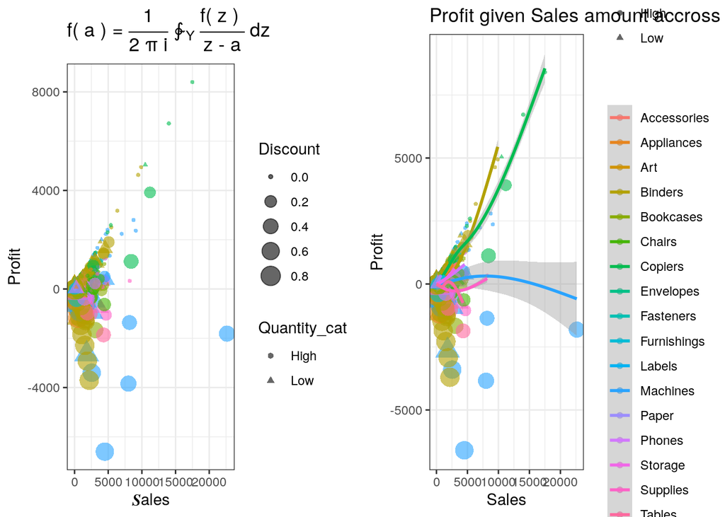

```r
library(ggrepel)
orders$Quantity_cat <- factor(ifelse(orders$Quantity > mean(orders$Quantity), "High", "Low"), levels = c("High", "Low"), ordered = FALSE)

ppt <- ggplot(orders, aes(x = Sales, y = Profit, col = Sub.Category)) +
  geom_point(alpha = 0.6, aes(size = Discount, shape = Quantity_cat)) +
  theme_bw() +
  geom_smooth() +
  guides(col = guide_legend(""), size = FALSE) +
  labs(title = "Profit given Sales amount accross categories")

ppl <- ggplot(orders, aes(x = Sales, y = Profit, col = Sub.Category)) +
  geom_point(alpha = 0.6, aes(size = Discount, shape = Quantity_cat)) +
  theme_bw() +
  guides(col = FALSE) +
  labs(title = TeX("f( a ) = \\frac{1}{2 π i}  ∲_Ύ \\frac{f( z ) }{z - a} dz"),
       x = "𝑺ales")


grid.arrange(grobs = list(ppt, ppl), layout_matrix = matrix(2:1, nrow = 1))
```

# Question 2 > Include Multiple measures into the visualisation

## Using Multiple Rows / Columns

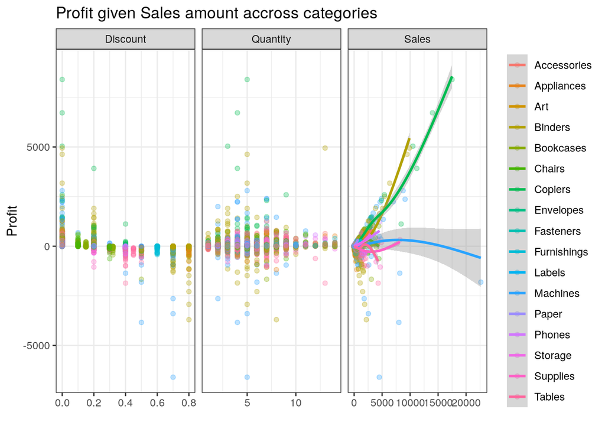

```r
orders_tidy <- pivot_longer(orders, cols = c(Quantity, Discount, Sales))


ggplot(orders_tidy, aes(x = value, y = Profit, col = Sub.Category)) +
  geom_point(alpha = 0.3) +
  facet_grid(. ~ name, scales = "free_x") +
  theme_bw() +
  geom_smooth() +
  guides(col = guide_legend("")) +
  labs(title = "Profit given Sales amount accross categories", x = "")
```

## Sharing the y-axis

Sharing y-axis is a little bit more work, first look at the the ratio between the data ranges, playing around with this will reveal that 20, 000 is a good ratio.

```r
range(orders$Sales)
```

```
## [1]     0.444 22638.480
```

```r
range(orders$Profit)
```

```
## [1] -6599.978  8399.976
```

Now the data can be modified, rescaled and a custom y-axis implemented:

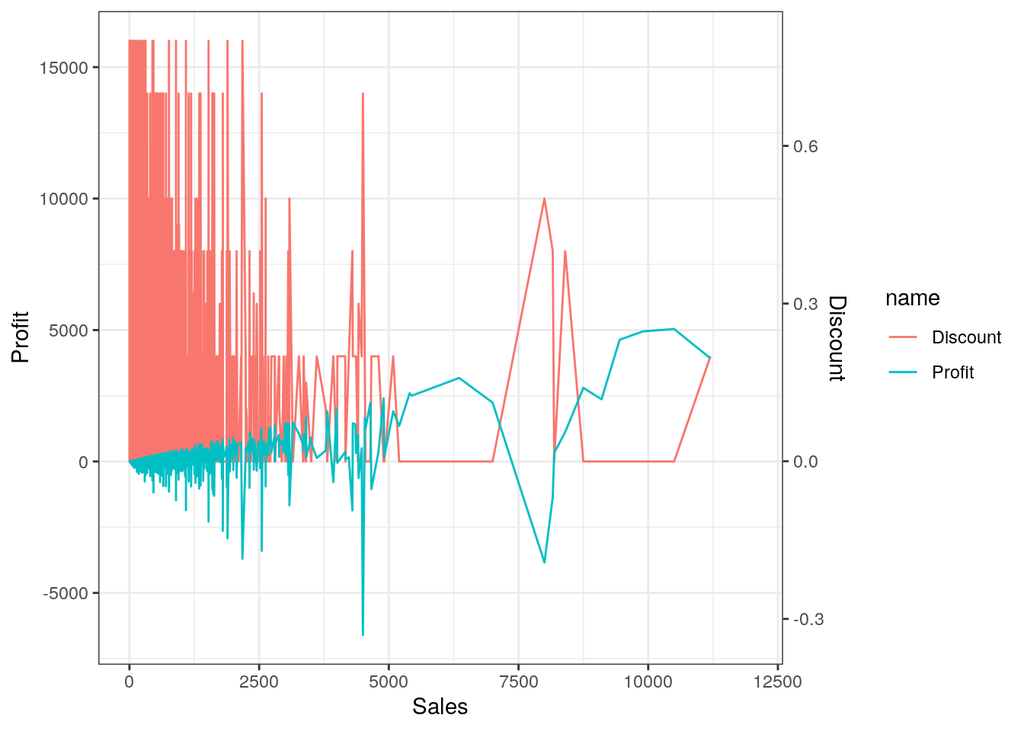

```r
orders_tidy <- pivot_longer(orders %>% mutate(Discount = Discount*20000), cols = c(Discount, Profit))
ggplot(orders_tidy, aes(x = Sales, y = value, col = name)) +
  geom_line() +
  scale_y_continuous(

    # Features of the first axis
    name = "Profit",

    # Add a second axis and specify its features
    sec.axis = sec_axis( trans=~.*(1/20000), name="Discount")
  ) +
  scale_x_continuous(limits = c(0, 12000)) +
  theme_bw()
```

# Question 3

> Implement a Dual-Axis Chart

A dual axis chart can be implemented by specifying a second axis as before:

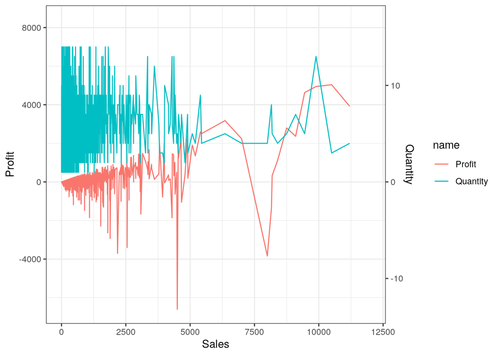

```r
r <- 500

orders_tidy <- pivot_longer(orders %>% mutate(Quantity = Quantity*r), cols = c(Quantity, Profit))

ggplot(orders_tidy, aes(x = Sales, y = value, col = name)) +
  geom_line() +
  scale_y_continuous(

    # Features of the first axis
    name = "Profit",

    # Add a second axis and specify its features
    sec.axis = sec_axis( trans=~.*(1/r), name="Quantity")
  ) +
  scale_x_continuous(limits = c(0, 12000)) +
  theme_bw()
```

# Question 4

> Implement a visualisation on the map

To generate a choropleth map, match names to map names:

```r
## state_names <- map("state", plot = FALSE)$name
## only_names  <- sapply(strsplit(state_names, ":"), "[", 1)
## index    <- match(only_names, tolower(state.name))
## index[8] <- 47
```

Then assign some colours:

```r
col_vec <- function(x, lowcol = "white", highcol = "red") {
  rgb(colorRamp(c(lowcol, highcol))((x-min(x))/(max(x)-min(x))),
      maxColorValue = 255)[index]
}
```

Then draw the map

```r
## profits_vec <- orders$Profit
## names(profits_vec) <- orders$State
##
## maps::map('state', fill = TRUE, col = col_vec(profits_vec, "white", "green"))
```

(There is a bug in `knitr` that prevents this from compiling) so Alternatively the `usmap` allows us to use the `usmap` library through the much more robust `ggplot2`:

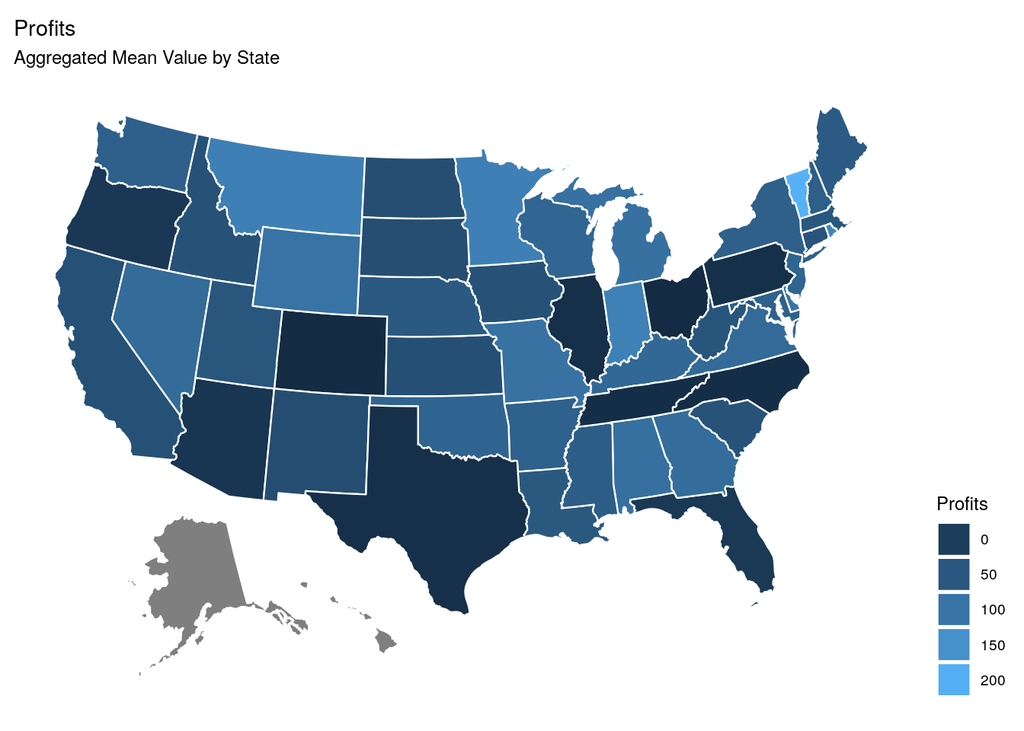

```r
library(usmap)
names(orders)[names(orders)=="State"] <- "state"
prof_df <- aggregate(Profit ~ state, orders, mean)


plot_usmap(regions = "state", data = prof_df, values = "Profit", col = "white") +
  labs(title = "Profits",
       subtitle = "Aggregated Mean Value by State")  +
  theme(legend.position = "right") +
  guides(fill = guide_legend("Profits"))
```

#

# Question 5

Qxplore Tablaue

This doesn’t translate to *R* and *GGPlot2* so I’ve left it.